# KBL_경기_득점차승수_예측_머신러닝&딥러닝_upl

[figure not shown]

```python
from IPython.display import Image
Image('kbl.jpg')
```

아직 국내에서는 스포츠 경기 예측에 대한 연구가 다른 산업에 비해 활발하지 않다고 한다.  
일반적 머신러닝을 스포츠 경기에 적용하고자 한다면, 예측데이터(예측변수)인 승패(또는 득점)는 미래의 경기에서 발생한다.  
즉 예측변수와 독립변수가 함께 발생한다.  
농구를 예를들면, 독립변수로 활용할 수 있는 2점슛,3점슛,리바운드는 경기가 진행되어야만 발생한다.  
따라서 일반적 머신러닝을 적용하기에는 제약사항이 따르므로 다음과 같은 방안을 고려해 볼 수 있다.

#### 2. 딥러닝 - 순환신경망, LSTM

아래는 한 팀의 1시즌 정규리그 경기 구성이다.

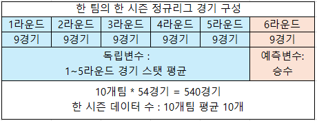

```python
Image('시즌경기수.png')
```

한 시즌의 경기 수는 540경기(54경기 * 10개팀)이며, 1~5라운드 10개 팀의 스탯 평균을 내면 한 시즌 데이터 수는 10개이다.  
22개 시즌이므로 총데이터수는 220개이다.

```python
import warnings

import pandas as pd
import numpy as np
import janitor

import matplotlib.pyplot as plt
import seaborn as sns
from collections import Counter
from pytictoc import TicToc

from sklearn.experimental import enable_iterative_imputer
from sklearn.impute import IterativeImputer
from imblearn.over_sampling import RandomOverSampler
from sklearn.model_selection import train_test_split
from sklearn.model_selection import GridSearchCV, KFold

from sklearn.preprocessing import OneHotEncoder
from sklearn.preprocessing import MinMaxScaler
from sklearn.preprocessing import StandardScaler

from imblearn.pipeline import Pipeline
from imblearn.pipeline import make_pipeline
from sklearn.compose import ColumnTransformer, make_column_transformer

from sklearn.ensemble import RandomForestRegressor, RandomForestClassifier
from sklearn.linear_model import LinearRegression
from catboost import CatBoostClassifier
import xgboost as xgb

from sklearn.metrics import r2_score, mean_absolute_error, mean_squared_error
from sklearn.metrics import confusion_matrix, classification_report, accuracy_score, balanced_accuracy_score, plot_roc_curve, roc_auc_score, roc_curve
from sklearn.model_selection import cross_val_score

import pickle
import joblib

plt.rcParams['font.family'] = 'Malgun Gothic'
warnings.filterwarnings('ignore')
pd.set_option('display.max_columns', None)
pd.set_option('display.max_rows', None)
```

#### 사전 EDA분석 후 다양한 변수로 구성된 6개의 데이터셋 생성

```python
df_all = pd.read_pickle('df_all.pkl')
```

```python
df_all.head()
```

|  | 팀명 | 상대팀명 | 시즌 | 총점수 | 승패 | p2점성공 | p2점성공률 | p3점성공 | p3점성공률 | 자유투성공 | 자유투성공률 | REB | AST | STL | BLK | 파울 | 속공 | TOV | 굿디펜스 | OR | DR | 누적승 | 차이_p2점성공 | 차이_p2점성공률 | 차이_p3점성공 | 차이_p3점성공률 | 차이_자유투성공 | 차이_자유투성공률 | 차이_REB | … |
| --- | --- | --- | --- | --- | --- | --- | --- | --- | --- | --- | --- | --- | --- | --- | --- | --- | --- | --- | --- | --- | --- | --- | --- | --- | --- | --- | --- | --- | --- | --- |
| 0 | DAYONE | KOGAS | 2002 | 87 | 0 | 26 | 49.1 | 6 | 35.3 | 17 | 85.0 | 33 | 17 | 6 | 6 | 23 | 5 | 17 | 8 | 11 | 22 | 0 | -4 | -8.6 | -2 | -9.1 | 6 | -6.7 | 1 | … |
| 1 | DB | LG | 2002 | 91 | 0 | 28 | 52.8 | 9 | 40.9 | 8 | 72.7 | 38 | 20 | 5 | 7 | 19 | 6 | 11 | 1 | 11 | 27 | 0 | 1 | -5.9 | -5 | -0.3 | 2 | 6.0 | 6 | … |
| 2 | KCC | SK | 2002 | 86 | 0 | 28 | 56.0 | 6 | 21.4 | 12 | 66.7 | 20 | 17 | 8 | 3 | 24 | 5 | 11 | 6 | 5 | 15 | 0 | 2 | -1.8 | 0 | -8.6 | -9 | -14.1 | -20 | … |
| 3 | KGC | MOBIS | 2002 | 77 | 0 | 37 | 62.7 | 0 | 0.0 | 3 | 75.0 | 31 | 16 | 10 | 3 | 20 | 3 | 15 | 2 | 12 | 19 | 0 | 10 | 5.3 | -6 | -46.2 | -7 | 16.2 | -5 | … |
| 4 | KOGAS | DAYONE | 2002 | 95 | 1 | 30 | 57.7 | 8 | 44.4 | 11 | 91.7 | 32 | 23 | 7 | 3 | 23 | 5 | 15 | 4 | 8 | 24 | 1 | 4 | 8.6 | 2 | 9.1 | -6 | 6.7 | -1 | … |

```python
df_all_1 = df_all[['팀명','상대팀명','시즌', '총점수', '승패', 'p2점성공률', 'p3점성공률',
       '자유투성공률', 'REB', 'AST', 'STL', 'BLK', '파울', '속공', 'TOV', '굿디펜스', 'OR',
       'DR', '누적승', '차이_p2점성공률', '차이_p3점성공률',
        '차이_자유투성공률', '차이_REB', '차이_AST', '차이_STL', '차이_BLK',
       '차이_파울', '차이_속공', '차이_TOV', '차이_굿디펜스', '차이_OR', '차이_DR', '차이_누적승']]
```

```python
df_all_our = df_all[['팀명', '상대팀명', '시즌', '총점수', '승패', 'p2점성공', 'p2점성공률', 'p3점성공',
       'p3점성공률', '자유투성공', '자유투성공률', 'REB', 'AST', 'STL', 'BLK', '파울', '속공',
       'TOV', '굿디펜스', 'OR', 'DR', '누적승']]
```

```python
df_all_our_1 = df_all_our[['팀명', '상대팀명', '승패', '시즌', 'p2점성공률',
       'p3점성공률', '자유투성공률', 'REB', 'AST', 'STL', 'BLK', '파울', '속공',
       'TOV', '굿디펜스', 'OR', 'DR', '누적승']]
```

```python
df_all_sub = df_all[['팀명', '상대팀명', '시즌', '총점수', '승패', '차이_p2점성공', '차이_p2점성공률', '차이_p3점성공',
       '차이_p3점성공률', '차이_자유투성공', '차이_자유투성공률', '차이_REB', '차이_AST', '차이_STL',
       '차이_BLK', '차이_파울', '차이_속공', '차이_TOV', '차이_굿디펜스', '차이_OR', '차이_DR',
       '차이_누적승']]
```

```python
df_all_sub_1 = df_all[['팀명', '상대팀명', '승패', '시즌','차이_p2점성공률',
       '차이_p3점성공률', '차이_자유투성공률', '차이_REB', '차이_AST', '차이_STL',
       '차이_BLK','차이_파울', '차이_속공', '차이_TOV', '차이_굿디펜스', '차이_OR', '차이_DR',
       '차이_누적승']]
```

```python
trdf_li = [df_all,df_all_1,df_all_our,df_all_our_1,df_all_sub,df_all_sub_1]
trdf_name = ['df_all','df_all_1','df_all_our','df_all_our_1','df_all_sub','df_all_sub_1']
```

#### 상관관계 ( 경기 기본 스탯으로 구성된 df_all_our_1데이터 )

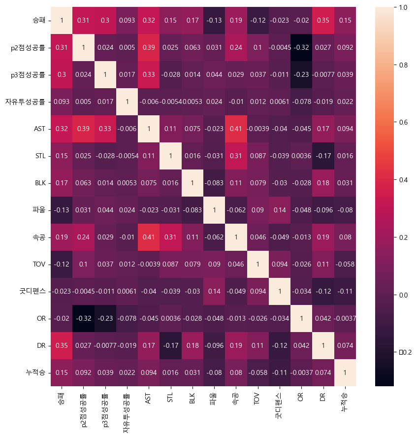

```python
plt.figure(figsize=(10,10))
corr = df_all_our_1.drop(['시즌','REB'],1).select_dtypes('number').corr()
sns.heatmap(corr, annot = True)
plt.show();
```

대부분의 변수 간 상관계수가 낮은 편이다.

#### 데이터 전처리 & 머신러닝(랜덤포레스트) 함수

```python
def mr_fun(dat0):
    dat_num = dat0.select_dtypes('number')
    dat_ca = dat0.select_dtypes('object').astype('category')
    dat = pd.concat([dat_num,dat_ca], axis = 1)
    #22시즌 나누기
    sedf_li = []
    seseon = np.unique(dat['시즌']).tolist()
    for i in range(len(seseon)):
        sedf_li.append(dat[dat['시즌']==seseon[i]])
    sedf_li[0]
    for i in range(len(sedf_li)):
        meandf = sedf_li[i][:450].groupby('팀명').mean()
        meandf['팀명']= meandf.index.tolist()
        resultdf = pd.DataFrame(sedf_li[i][:450].groupby('팀명').sum()['승패'])
        resultdf.columns =['R6승패']
        meandf = pd.concat([meandf,resultdf],1)
        if i==0:
            dat = meandf.reset_index(drop=True)
        else:
            dat = pd.concat([dat,meandf],0).reset_index(drop=True)

    y = dat['R6승패']
    X = dat.drop(['R6승패'], axis = 1)
    X_train = X[:180]
    X_test = X[180:]
    y_train = y[:180]
    y_test = y[180:]
    X_train.tail(10)

    num_columns = X_train.select_dtypes('number').columns.tolist()
    cat_columns = X_train.select_dtypes('category').columns.tolist()
    num_preprocess = make_pipeline( MinMaxScaler() )
    cat_preprocess = make_pipeline( OneHotEncoder(handle_unknown="ignore", sparse=False) )
    preprocess = ColumnTransformer(
    [("num", num_preprocess, num_columns),
    ("cat", cat_preprocess, cat_columns)]#,remainder='passthrough'
    )

    cv = KFold(n_splits = 10, shuffle = True, random_state = 0)
    full_pipe = Pipeline(
    [("preprocess", preprocess),("regressor", RandomForestRegressor())])
    RandomForest_param = {'regressor__max_features': np.arange(0.5, 1, 0.1)}
    RandomForest_search = GridSearchCV(estimator = full_pipe,
                      param_grid = RandomForest_param,
                      cv = cv,
                      scoring = 'neg_mean_squared_error')
    RandomForest_search.fit(X_train, y_train)
    return(RandomForest_search.predict(X_test),y_test,np.sqrt(np.absolute(RandomForest_search.score(X_test, y_test))))
```

머신러닝 모델 학습 & 예측 성능평가

```python
res_mr = []
res_mr_name = []
for i in range(len(trdf_li)):
    res_mr_name.append(trdf_name[i])
    _,_,rmse=mr_fun(trdf_li[i])
    res_mr.append(rmse)
```

성능평가 결과

```python
pd.DataFrame({'df':res_mr_name,'rmse':res_mr})
```

|  | df | rmse |
| --- | --- | --- |
| 0 | df_all | 0.334955 |
| 1 | df_all_1 | 0.342374 |
| 2 | df_all_our | 0.312810 |
| 3 | df_all_our_1 | 0.281301 |
| 4 | df_all_sub | 0.223159 |
| 5 | df_all_sub_1 | 0.290762 |

가장 좋은 결과는 df_all_sub데이터 변수 구성이다.

```python
pred_rf,y_test,rmse=mr_fun(df_all_sub)
rmse
```

```
0.23766047210253552
```

```python
pd.DataFrame({'pred':pred_rf,'R6_실제승패수':y_test })
```

|  | pred | R6_실제승패수 |
| --- | --- | --- |
| 180 | 26.15 | 26 |
| 181 | 16.93 | 17 |
| 182 | 29.96 | 30 |
| 183 | 24.03 | 24 |
| 184 | 22.99 | 23 |
| 185 | 23.94 | 24 |
| 186 | 14.93 | 15 |
| 187 | 28.01 | 28 |
| 188 | 19.91 | 20 |
| 189 | 18.15 | 18 |
| 190 | 21.05 | 21 |
| 191 | 19.96 | 20 |
| 192 | 18.07 | 18 |
| 193 | 26.91 | 27 |
| 194 | 20.00 | 20 |
| 195 | 29.94 | 30 |
| 196 | 18.67 | 19 |
| 197 | 26.08 | 26 |
| 198 | 9.44 | 9 |
| 199 | 34.01 | 35 |
| 200 | 23.97 | 24 |
| 201 | 17.07 | 17 |
| 202 | 20.00 | 20 |
| 203 | 32.84 | 33 |
| 204 | 16.03 | 16 |
| 205 | 18.68 | 19 |
| 206 | 29.68 | 30 |
| 207 | 26.74 | 27 |
| 208 | 12.15 | 12 |
| 209 | 26.84 | 27 |
| 210 | 14.91 | 15 |
| 211 | 35.03 | 35 |
| 212 | 25.11 | 25 |
| 213 | 13.97 | 14 |
| 214 | 17.99 | 18 |
| 215 | 29.03 | 29 |
| 216 | 28.07 | 28 |
| 217 | 24.01 | 24 |
| 218 | 9.36 | 10 |
| 219 | 26.70 | 27 |

## 2. 딥러닝 순환신경망 LSTM

```python
import warnings

import os
from pytictoc import TicToc
from datetime import datetime
import pandas as pd
import numpy as np
import pickle
import joblib

import seaborn as sns
import matplotlib.pyplot as plt

import pickle
import joblib

import tensorflow as tf
from tensorflow.python.keras.models import load_model # 모델 저장하기
from tensorflow.keras.models import Model, Sequential
from tensorflow.keras.layers import Input, Layer, Dense, LSTM, Conv1D, Lambda
from tensorflow.keras.losses import Huber
from tensorflow.keras.optimizers import Adam
from tensorflow.keras.callbacks import EarlyStopping, ModelCheckpoint

from sklearn.preprocessing import StandardScaler
from sklearn.metrics import r2_score, mean_absolute_error, mean_squared_error # 성능평가

warnings.filterwarnings('ignore')
pd.set_option('display.max_columns', None)
```

#### 사용 데이터 : 시계열 LSTM을 위해 순서 전처리된 데이터

데이터프레임은 날짜 & 팀명 순서로 정렬되게 처리함.  
10개의 팀명 순서 : 'DAYONE' 'LG' 'KGC' 'SAMSUNG' 'MOBIS' 'KT' 'DB' 'KCC' 'KOGAS' 'SK'  
ex) 100개의 데이터는 팀명순서(10개)X10(날짜순)으로 정렬됨.

```python
team_df = pd.read_csv(r'kbl_Team_02_24.csv')
team_df.rename(columns = {'상대팀':'상대팀명'}, inplace = True)
team_df = reorder_teams(team_df)
team_df['날짜'] = pd.to_datetime(team_df['날짜'])
team_df['득점우위시간'] = pd.to_numeric(team_df['득점우위시간'], errors='coerce')
```

```python
df2024 = team_df.loc[team_df['시즌'] >= 2018]
df2024 = df2024.loc[df2024['시즌'] != 2020]
dfse = df2024
dfse = dfse.reset_index(drop=True)
print(np.unique(dfse['팀명']) )
print(dfse.shape)
dfse.head()
```

```
['DAYONE' 'DB' 'KCC' 'KGC' 'KOGAS' 'KT' 'LG' 'MOBIS' 'SAMSUNG' 'SK']
(3240, 34)
```

|  | 날짜 | 팀명 | 총점수 | 시즌 | 상대팀명 | 승패 | 득점차 | p2점성공 | p2점시도 | p2점성공률 | p3점성공 | p3점시도 | p3점성공률 | 자유투성공 | 자유투시도 | 자유투성공률 | REB | AST | STL | BLK | 파울 | 속공 | TOV | 페인트존성공 | 굿디펜스 | 속공득점 | 턴오버기반득점 | 세컨찬스득점 | 벤치득점 | … |
| --- | --- | --- | --- | --- | --- | --- | --- | --- | --- | --- | --- | --- | --- | --- | --- | --- | --- | --- | --- | --- | --- | --- | --- | --- | --- | --- | --- | --- | --- | --- |
| 0 | 2017-10-14 | DAYONE | 74 | 2018 | LG | 0 | -7 | 18 | 33 | 54.5 | 11 | 28 | 39.3 | 5 | 12 | 41.7 | 37 | 16 | 3 | 7 | 27 | 4 | 14 | 14 | 1 | 7 | 9 | 9 | 27 | … |
| 1 | 2017-10-14 | LG | 81 | 2018 | DAYONE | 1 | 7 | 21 | 44 | 47.7 | 7 | 21 | 33.3 | 18 | 29 | 62.1 | 32 | 20 | 9 | 1 | 17 | 7 | 6 | 16 | 0 | 17 | 16 | 13 | 29 | … |
| 2 | 2017-10-14 | KGC | 70 | 2018 | SAMSUNG | 0 | -12 | 19 | 39 | 48.7 | 8 | 23 | 34.8 | 8 | 13 | 61.5 | 28 | 12 | 6 | 1 | 21 | 1 | 14 | 16 | 4 | 2 | 14 | 7 | 26 | … |
| 3 | 2017-10-14 | SAMSUNG | 82 | 2018 | KGC | 1 | 12 | 18 | 38 | 47.4 | 11 | 26 | 42.3 | 13 | 19 | 68.4 | 36 | 20 | 7 | 2 | 19 | 6 | 15 | 17 | 1 | 16 | 12 | 7 | 22 | … |
| 4 | 2017-10-14 | MOBIS | 81 | 2018 | KT | 1 | 8 | 22 | 47 | 46.8 | 8 | 19 | 42.1 | 13 | 19 | 68.4 | 31 | 17 | 5 | 2 | 11 | 1 | 6 | 19 | 1 | 2 | 9 | 16 | 35 | … |

중복요소가 있는 변수는 모두 제거한다. ex) 'p2점성공률'은 'p2점성공','p2점시도'로 만든 변수

```python
msft = dfse.drop(['날짜','팀명','시즌','상대팀명','승패','p2점성공','p2점시도','p3점성공','p3점시도','자유투성공','자유투시도'], 1)
```

#### 독립변수 : 경기 스탯('2점 득점','3점 득점','리바운드','블럭킹'... 등)

'득점차'가 음수이면 패를 의미하며, 양수이면 승을 의미한다.

```python
x = msft.drop('득점차', 1)
y = msft['득점차']
```

```python
# 정규화
scaler_x = StandardScaler()
x = scaler_x.fit_transform(x)
y = y.values.reshape(dfse.shape[0],1)
scaler_y = StandardScaler()
y = scaler_y.fit_transform(y)
```

#### 데이터 분할

훈련데이터 : 3200경기  
테스트데이터 : 40경기(실제 예측은 30경기)

```python
n_pre = 40
n_train = dfse.shape[0]-n_pre
seq_len = 10
pred_days = 1
```

```python
train = x[:n_train]
test= x[n_train:]

trainX = []
trainY = []
for i in range(seq_len, n_train-pred_days +1):
    trainX.append(train[i - seq_len:i, 0:train.shape[1]])
    trainY.append(train[i + pred_days - 1:i + pred_days, 0])

testX = []
testY = []
for i in range(seq_len, len(test)-pred_days +1):
    testX.append(test[i - seq_len:i, 0:test.shape[1]])
    testY.append(test[i + pred_days - 1:i + pred_days, 0])

trainX, trainY = np.array(trainX), np.array(trainY)
testX, testY = np.array(testX), np.array(testY)
```

#### 모델 학습

```python
hl_num1= 256
hl_num2= 64
learning_rate = 0.01
epoch = 60
batchsize=32
val_rate = 0.1
```

```python
model = Sequential()
model.add(LSTM(hl_num1, input_shape=(trainX.shape[1], trainX.shape[2]),return_sequences=True))
model.add(LSTM(hl_num2, return_sequences=False))
model.add(Dense(trainY.shape[1]))
model.summary()

optimizer = Adam(learning_rate=learning_rate)
model.compile(optimizer=optimizer, loss='mse', metrics=['mse'])
#early_stop = EarlyStopping(monitor='val_loss', patience=5)
filename = os.path.join('tmp_checkpoint_upl.h5')
checkpoint = ModelCheckpoint(filename, monitor='val_loss', save_best_only=True, mode='auto')
history = model.fit(trainX, trainY, epochs=epoch, batch_size=batchsize, validation_split=val_rate, verbose=0,
                   callbacks=[checkpoint])#callbacks=[early_stop, checkpoint])
```

```
Model: "sequential_7"
_________________________________________________________________
 Layer (type)                Output Shape              Param #
=================================================================
 lstm_12 (LSTM)              (None, 10, 256)           285696

 lstm_13 (LSTM)              (None, 64)                82176

 dense_6 (Dense)             (None, 1)                 65

=================================================================
Total params: 367,937
Trainable params: 367,937
Non-trainable params: 0
_________________________________________________________________
```

#### 예측 및 평가

```python
model.load_weights(filename)
prediction = model.predict(testX)

pred0 = scaler_y.inverse_transform(prediction)
testY0 = scaler_y.inverse_transform(testY)

print(f"MAPE : {np.mean(np.abs((testY0 - pred0 ) / testY0)):.4f}")
print(f"RMSE : {np.sqrt(mean_squared_error(testY0,pred0 )):.4f}")
print(f"MAE : {mean_absolute_error(testY0,pred0):.4f}")
```

```
MAPE : 1.2622
RMSE : 11.2991
MAE : 7.8285
```

```python
def reorder_teams(df):
    reorder_data = []

    # 데이터프레임을 날짜로 그룹화
    grouped = df.groupby('날짜')

    for name, group in grouped:
        group = group.reset_index(drop=True)
        matched_indices = set()
        for i in range(len(group)):
            if i in matched_indices:
                continue
            for j in range(i + 1, len(group)):
                if group.loc[i, '팀명'] == group.loc[j, '상대팀명'] and group.loc[i, '상대팀명'] == group.loc[j, '팀명']:
                    reorder_data.append(list(group.iloc[i]))
                    reorder_data.append(list(group.iloc[j]))
                    matched_indices.add(i)
                    matched_indices.add(j)
                    break

    # 새로운 데이터프레임 생성
    reorder_df = pd.DataFrame(reorder_data, columns=df.columns)

    return reorder_df
```